# Week 2 - Quarto for R

CHL5233 Fall 2026

## Quarto

- Quarto is a publishing platform for technical and scientific documents
- You can create documents (HTML, PDF, Word) where text and code coexist
- Outputs include reports, presentations, websites, books, and more
- You can include code written in R, Python, Julia, or Observable
- These slides were created in Quarto

## R or qmd?

**R file should still be used for**

- **Developing** and **testing** code
- Creating functions and scripts to call using `source()`
- Writing code for **packages**
- Working with long data **cleaning** or **pre-processing**

**Quarto should be used for**

- When the eventual goal is to **render** the document
- Creating **reproducible** documents in HTML, PDF, Word
- Presenting code and analysis results with **explanation**
- Generating presentation **slides** in HTML, Beamer, PPT

## Text in Quarto

- Quarto uses a [Markdown](https://quarto.org/docs/authoring/markdown-basics.html) format
- Mathematical syntax and equations can be included in a similar manner to LaTex

$$Y = \alpha + \beta X$$

## Code chunks in Quarto

```r
data(cars)
head(cars)
```

```
  speed dist
1     4    2
2     4   10
3     7    4
4     7   22
5     8   16
6     9   10
```

```r
plot(cars$speed ~ cars$dist)
```

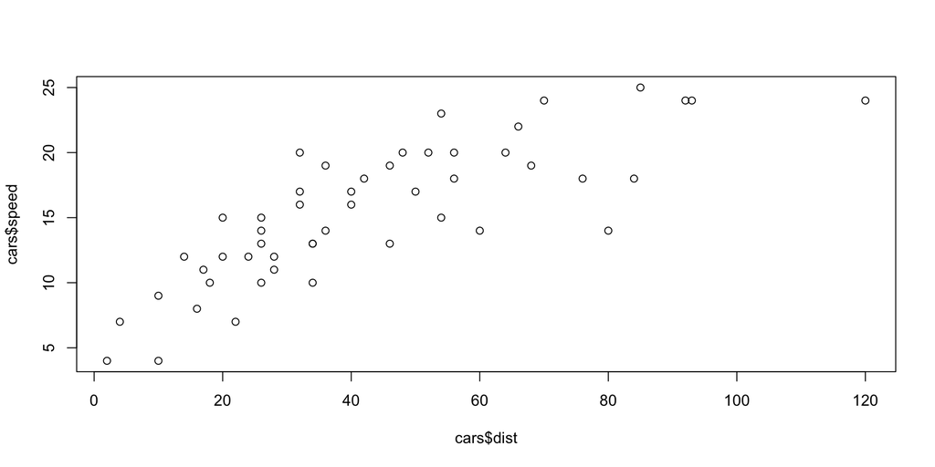

## Quick exercise

- Reproduce these slides by rendering `02_quarto.qmd`
- Complete the [markdown tutorial](https://commonmark.org/help/tutorial/)
- Useful documentations
  - [Quarto](https://quarto.org/)
  - [Authoring with Positron](https://quarto.org/docs/get-started/authoring/positron.html)
  - [Chapter 29 in R for Data Science](https://r4ds.hadley.nz/quarto.html)
  - [Chapter 3.2 in Telling Stories with Data](https://tellingstorieswithdata.com/03-workflow.html#quarto)
- Best way to learn Quarto is to actually use it!

## In-class assignment

- Available in this week’s module
- Work in groups

## Next week

- Preparing data for analysis - functions and loops
- Experiment with AI-assisted coding
- We will create an analytical data set from multiple open source data sets